# MD5

```r
library(tidyverse)
twitch_data <- read_csv("https://raw.githubusercontent.com/vaiseys/dav-course/main/Data/twitchdata-update.csv")
```

## MD 5

```r
library(janitor)
twitch_data <- clean_names(twitch_data)

# Inspect new names
colnames(twitch_data)
```

```
 [1] "channel"             "watch_time_minutes"  "stream_time_minutes"
 [4] "peak_viewers"        "average_viewers"     "followers"
 [7] "followers_gained"    "views_gained"        "partnered"
[10] "mature"              "language"
```

## Question 1

```r
evals_twitchdata <- twitch_data %>%
  select(average_viewers, followers)
glimpse(evals_twitchdata)
```

```
Rows: 1,000
Columns: 2
$ average_viewers <dbl> 27716, 25610, 10976, 7714, 29602, 42414, 24181, 18985,…
$ followers       <dbl> 3246298, 5310163, 1767635, 3944850, 8938903, 1563438, …
```

```r
evals_twitchdata <- twitch_data |>
  sample_n(size = 5) |>
  select(channel, average_viewers, followers)

evals_twitchdata
```

```
# A tibble: 5 × 3
  channel        average_viewers followers
  <chr>                    <dbl>     <dbl>
1 DisguisedToast            9892   1340283
2 Dementardo                4663    547154
3 tebtv                     2177     76050
4 LeBouseuh                 3678    988237
5 Tonton                    1237    147542
```

I see that the more average viewers does not necessarily lead to more followers, but the one’s that have more average views will generally have more followers.

```r
q1 <- twitch_data |>
  select(channel, average_viewers, followers)

summary(q1)
```

```
   channel          average_viewers    followers
 Length:1000        Min.   :   235   Min.   :   3660
 Class :character   1st Qu.:  1458   1st Qu.: 170546
 Mode  :character   Median :  2425   Median : 318063
                    Mean   :  4781   Mean   : 570054
                    3rd Qu.:  4786   3rd Qu.: 624332
                    Max.   :147643   Max.   :8938903
```

The mean is 4781 for average viewers and 570054 for followers while the median is 2425 for average viewers and 318063 for followers. This captured my attention because the mean is bigger than the median for both, so it tells me that there may be a variety of different numbers ranging from high to middle.

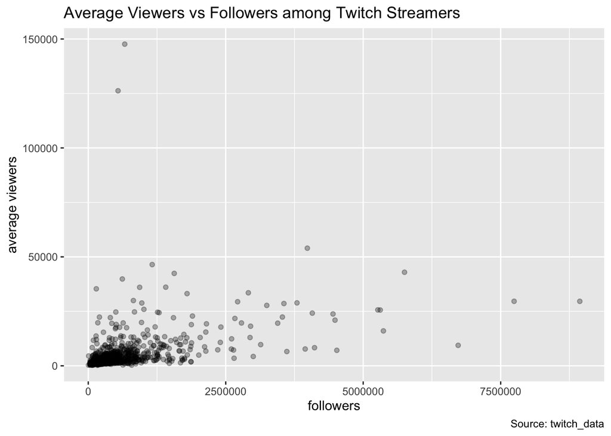

```r
ggplot(twitch_data,
       mapping = aes(x = followers,
                     y = average_viewers)) +
  geom_jitter(alpha = 0.3) +
  labs(title = "Average Viewers vs Followers among Twitch Streamers", caption = "Source: twitch_data", x = "followers", y = "average viewers")
```

There is a hot spot near the origin and only a few outliers who are the more famous content creators. Majority are low-low.

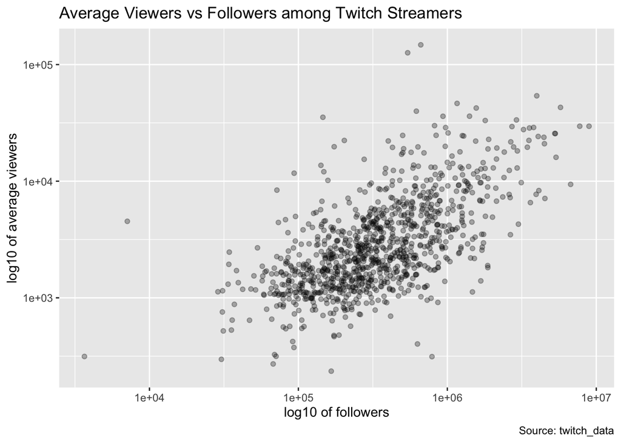

```r
ggplot(twitch_data,
       mapping = aes(x = followers,
                     y = average_viewers)) +
  geom_jitter(alpha = 0.3) +
  labs(title = "Average Viewers vs Followers among Twitch Streamers", caption = "Source: twitch_data", x = "log10 of followers", y = "log10 of average viewers") +
  scale_x_log10() +
  scale_y_log10()
```

This helps see the positive relationship between the two and not as many outliers.

```r
twitch_data <- twitch_data %>%
  mutate(log_viewers = log10(average_viewers),
         log_followers = log10(followers))
```

## Question 2

```r
fit1 <- lm(log_viewers ~ log_followers,
           data = twitch_data)

broom::tidy(fit1)
```

```
# A tibble: 2 × 5
  term          estimate std.error statistic   p.value
  <chr>            <dbl>     <dbl>     <dbl>     <dbl>
1 (Intercept)      0.198    0.125       1.58 1.15e-  1
2 log_followers    0.588    0.0226     26.0  1.69e-114
```

```r
fit1
```

```
Call:
lm(formula = log_viewers ~ log_followers, data = twitch_data)

Coefficients:
  (Intercept)  log_followers
       0.1978         0.5885
```

```r
#/ followers is the independent variable and viewers is the dependent variable!
```

$$1.1^{0.59} = 1.0578 $$

I see that when there is a 10% increase in followers, there is expected 5.78% increase in average viewers.

## Question 3

```r
library(broom)

pred_data <- augment(fit1)

# glimpse our new data
glimpse(pred_data)
```

```
Rows: 1,000
Columns: 8
$ log_viewers   <dbl> 4.442731, 4.408410, 4.040444, 3.887280, 4.471321, 4.6275…
$ log_followers <dbl> 6.511388, 6.725108, 6.247393, 6.596030, 6.951284, 6.1940…
$ .fitted       <dbl> 4.029761, 4.155534, 3.874400, 4.079572, 4.288638, 3.8430…
$ .resid        <dbl> 0.4129697, 0.2528757, 0.1660436, -0.1922928, 0.1826833, …
$ .hat          <dbl> 0.006194481, 0.008694557, 0.003782169, 0.007126066, 0.01…
$ .sigma        <dbl> 0.3085580, 0.3087321, 0.3087919, 0.3087764, 0.3087820, 0…
$ .cooksd       <dbl> 0.0056128779, 0.0029688873, 0.0005513456, 0.0014026033, …
$ .std.resid    <dbl> 1.3420109, 0.8227954, 0.5389316, -0.6251793, 0.5953620, …
```

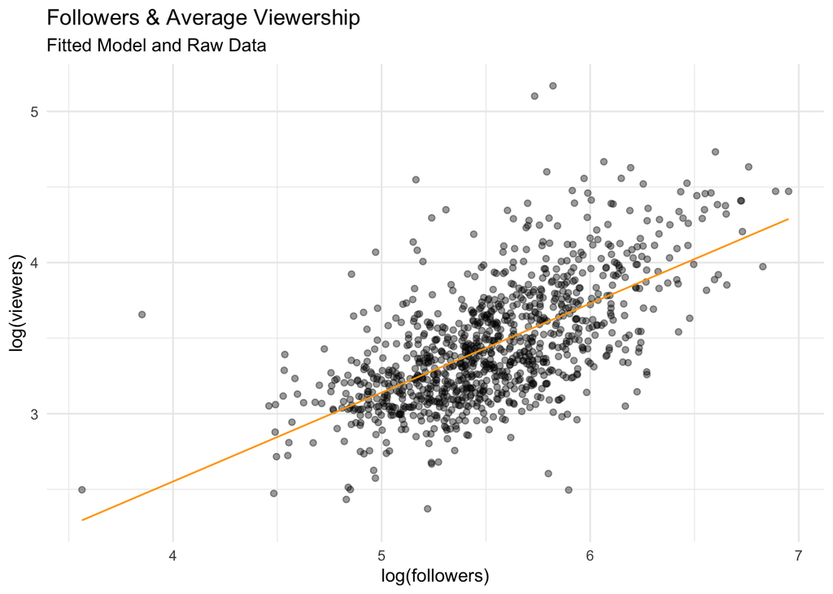

```r
pred_data %>%
  ggplot(aes(x = log_followers,
             y = log_viewers)) +
  geom_jitter(alpha = 0.4) +
  geom_line(aes(x = log_followers,
                y = .fitted),
            col = "orange") +
  theme_minimal() +
  labs(subtitle = "Fitted Model and Raw Data",
       title = "Followers & Average Viewership",
       x = "log(followers)",
       y = "log(viewers)")
```

This helps visualize the upward, positive relationship between the two.

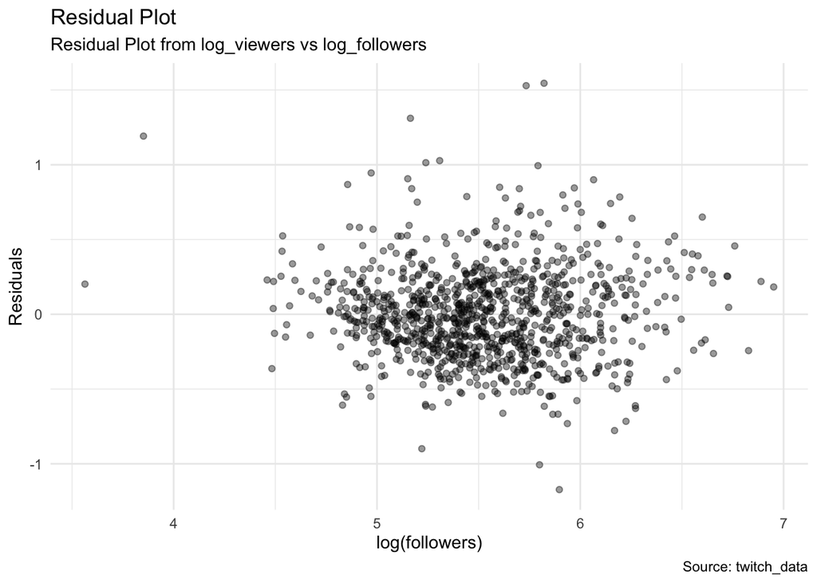

```r
pred_data |>
  ggplot(aes(x = log_followers,
             y = .resid)) +
  geom_jitter(alpha = 0.4) +
  theme_minimal() +
  labs(subtitle = "Residual Plot from log_viewers vs log_followers",
       title = "Residual Plot",
       x = "log(followers)",
       y = "Residuals",
       caption = "Source: twitch_data")
```

This shows the distance from each point to the model on the other graph. Most residuals are around 0 with some outliers above 1 and below -1, but it is not often so it is a good fit.

## Question 4

```r
lang <- twitch_data |>
  select(channel, language, average_viewers)

lang
```

```
# A tibble: 1,000 × 3
   channel    language   average_viewers
   <chr>      <chr>                <dbl>
 1 xQcOW      English              27716
 2 summit1g   English              25610
 3 Gaules     Portuguese           10976
 4 ESL_CSGO   English               7714
 5 Tfue       English              29602
 6 Asmongold  English              42414
 7 NICKMERCS  English              24181
 8 Fextralife English              18985
 9 loltyler1  English              22381
10 Anomaly    English              12377
# ℹ 990 more rows
```

```r
lang |>
  sample_n(size = 25)
```

```
# A tibble: 25 × 3
   channel       language   average_viewers
   <chr>         <chr>                <dbl>
 1 Staiy         German                3711
 2 Alinity       English               2441
 3 mandiocaa1    Portuguese            4355
 4 NymN          English               3402
 5 Deadlyslob    English               3088
 6 Northernlion  English               3968
 7 ESL_CSGO      English               7714
 8 NeVeR_LosEs   Chinese               3680
 9 PaymoneyWubby English               5485
10 Rubius        Spanish              42948
# ℹ 15 more rows
```

Here, I see that English language is more consistent with more average viewers, but that is not a concrete fact. We can see the popular Turkish yet also not popular Korean.

```r
summary(lang)
```

```
   channel            language         average_viewers
 Length:1000        Length:1000        Min.   :   235
 Class :character   Class :character   1st Qu.:  1458
 Mode  :character   Mode  :character   Median :  2425
                                       Mean   :  4781
                                       3rd Qu.:  4786
                                       Max.   :147643
```

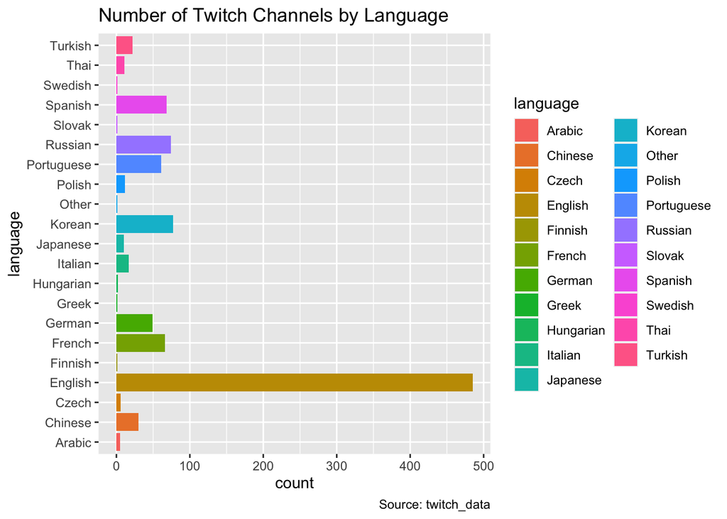

```r
ggplot(lang,
       mapping = aes(x = language,
                     fill = language)) +  geom_bar() + coord_flip() +
  labs(title = "Number of Twitch Channels by Language", caption = "Source: twitch_data")
```

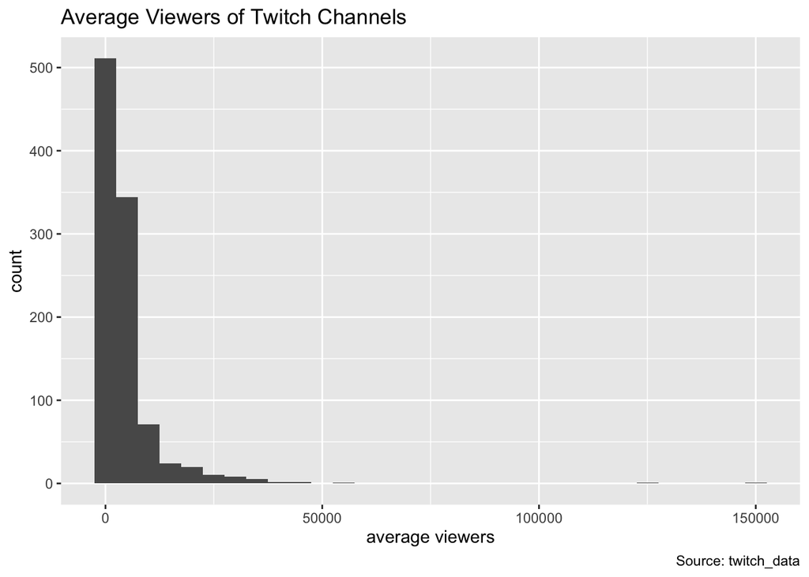

```r
ggplot(lang,
       aes(x = average_viewers)) +
  geom_histogram(binwidth = 5000) +
  labs(title = "Average Viewers of Twitch Channels", x = "average viewers", caption = "Source: twitch_data")
```

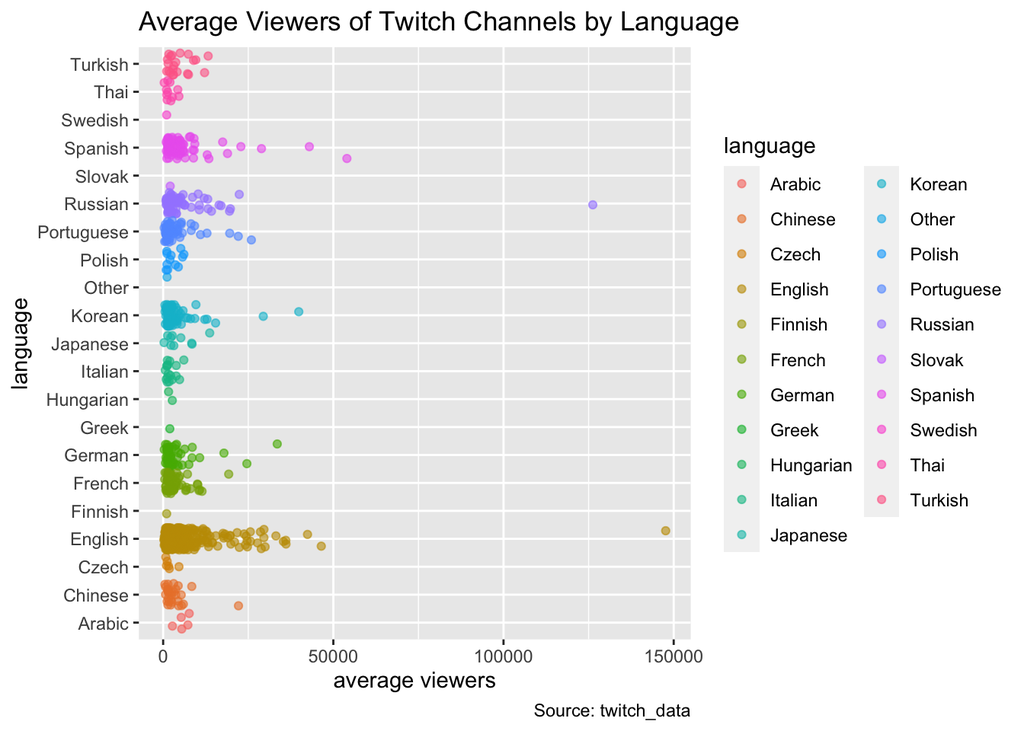

```r
ggplot(lang,
       mapping = aes(x = language,
                     y = average_viewers,
                     color = language)) +
  geom_jitter(alpha = 0.6) +
  coord_flip() +
  labs(title = "Average Viewers of Twitch Channels by Language", x = "language", y = "average viewers", caption = "Source: twitch_data")
```

Here, we can see that English streamers do generally dominate the average viewers. Some languages have occasional outliers like Russian and English. It makes me believe that it probably has to do with the culture and whether streaming is popular wherever the stream takes place.

## Question 5

```r
twitch_data <- twitch_data %>%
  mutate(language = as.factor(language),
         language = relevel(language, ref = "English"))
```

```r
fit2 <- lm(average_viewers ~ language,
           data = lang)

broom::tidy(fit2)
```

```
# A tibble: 21 × 5
   term              estimate std.error statistic p.value
   <chr>                <dbl>     <dbl>     <dbl>   <dbl>
 1 (Intercept)          5682.     3788.     1.50    0.134
 2 languageChinese     -2257.     4092.    -0.552   0.581
 3 languageCzech       -3855.     5129.    -0.751   0.453
 4 languageEnglish      -569.     3808.    -0.150   0.881
 5 languageFinnish     -4655.     9279.    -0.502   0.616
 6 languageFrench      -2176.     3929.    -0.554   0.580
 7 languageGerman      -1404.     3977.    -0.353   0.724
 8 languageGreek       -3721.     9279.    -0.401   0.688
 9 languageHungarian   -3542.     7087.    -0.500   0.617
10 languageItalian     -3477.     4310.    -0.807   0.420
# ℹ 11 more rows
```

```r
fit2
```

```
Call:
lm(formula = average_viewers ~ language, data = lang)

Coefficients:
       (Intercept)     languageChinese       languageCzech     languageEnglish
            5682.2             -2257.4             -3854.5              -569.4
   languageFinnish      languageFrench      languageGerman       languageGreek
           -4655.2             -2175.7             -1404.0             -3721.2
 languageHungarian     languageItalian    languageJapanese      languageKorean
           -3541.7             -3476.7              -919.6             -1768.3
     languageOther      languagePolish  languagePortuguese     languageRussian
           -4533.2             -2776.9             -1881.3               912.0
    languageSlovak     languageSpanish     languageSwedish        languageThai
           -3610.2               767.5             -4655.2             -3670.8
   languageTurkish
            -921.3
```

```r
#/ followers is the independent variable and viewers is the dependent variable!
```

```r
twitch_data |>
  summarize(standard_deviation = sd(average_viewers, na.rm = TRUE))
```

```
# A tibble: 1 × 1
  standard_deviation
               <dbl>
1              8454.
```

Spanish, Arabic, and Russian all have more average viewers than the English language. There are more negative coefficients than positive and we can see from the standard deviation that the prediction is right so far.

## Question 6

```r
library(broom)

yes <- augment(fit2)

# glimpse our new data
glimpse(yes)
```

```
Rows: 1,000
Columns: 8
$ average_viewers <dbl> 27716, 25610, 10976, 7714, 29602, 42414, 24181, 18985,…
$ language        <chr> "English", "English", "Portuguese", "English", "Englis…
$ .fitted         <dbl> 5112.814, 5112.814, 3800.934, 5112.814, 5112.814, 5112…
$ .resid          <dbl> 22603.186, 20497.186, 7175.066, 2601.186, 24489.186, 3…
$ .hat            <dbl> 0.002061856, 0.002061856, 0.016393443, 0.002061856, 0.…
$ .sigma          <dbl> 8444.313, 8449.818, 8472.094, 8474.843, 8438.923, 8390…
$ .cooksd         <dbl> 7.019555e-04, 5.772431e-04, 5.788931e-04, 9.296361e-06…
$ .std.resid      <dbl> 2.6710814, 2.4222095, 0.8540523, 0.3073893, 2.8939553,…
```

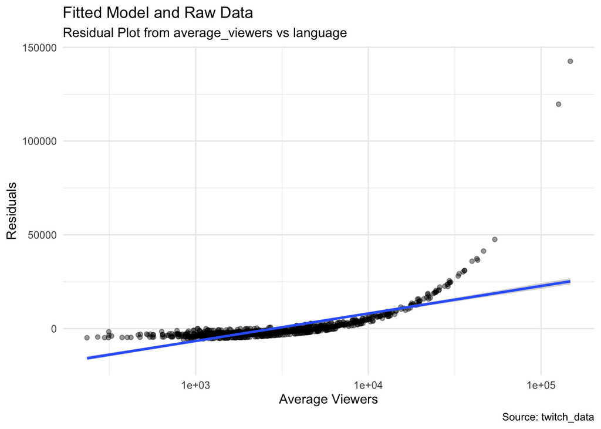

```r
ggplot(yes,
       aes(x = average_viewers,
           y = .resid)) +
  geom_jitter(alpha = 0.4) +
  geom_smooth(method = lm) +
  theme_minimal() +
  labs(subtitle = "Residual Plot from average_viewers vs language",
       title = "Fitted Model and Raw Data",
       x = "Average Viewers",
       y = "Residuals",
       caption = "Source: twitch_data") +
  scale_x_log10()
```

Our model missed the two points above that are separated called dota2ti and dota2ti_ru. The first is English and the second is Russian.